# Time Series: A First Course with Bootstrap Starter

# Lesson 3-3: Examples of Filters

- We explore smoothers, differencing, and the backshift operator.

## Paradigm 3.3.1. Smoother

- Linear filters that suppress oscillations and reveal long-term trends are called *smoothers*.
- A simple moving average is an example of a smoother.

## Example 3.3.2. Smoothers Applied to Gasoline Sales

- We apply a simple moving average with $m=10$ to the logged seasonally adjusted gasoline series.

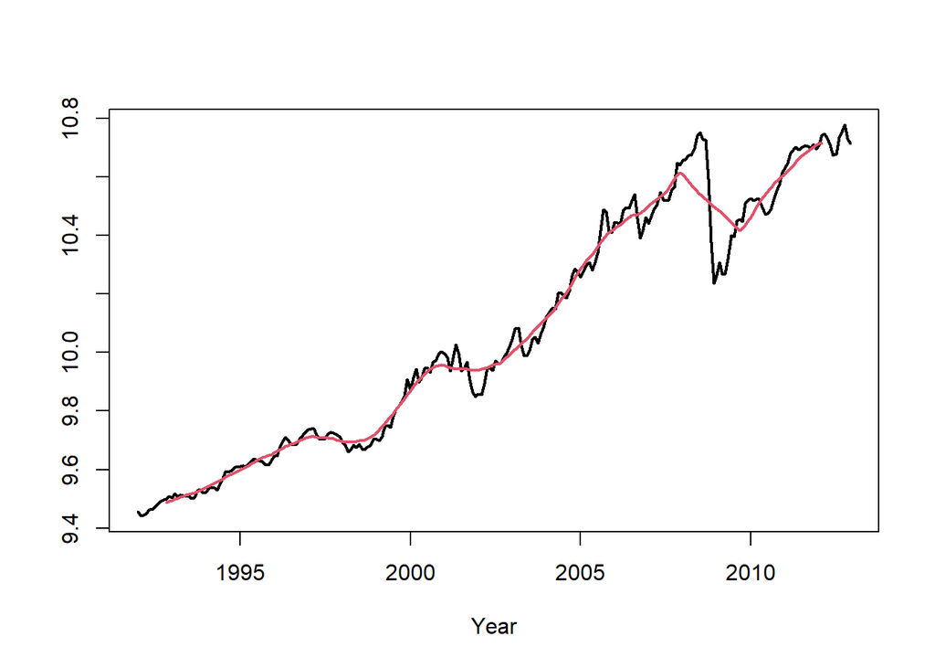

```r
gassa <- read.table("GasSA_2-11-13.dat")
gassa.log <- ts(log(gassa),start=1992,frequency=12)

h <- 10
simple.ma <- rep(1,2*h+1)/(2*h+1)
gas.trend <- stats::filter(gassa.log,simple.ma,method="convolution",sides=2)
gas.trend <- ts(gas.trend,start=1992,frequency=12)
plot(ts(gassa.log,start=1992,frequency=12),col=1,ylab="",xlab="Year",lwd=2)
lines(ts(gas.trend,start=1992,frequency=12),col=2,lwd=2)
```

- We can run a visualization in the notebook.

```r
### Movie
movie <- FALSE
delay <- 0
flex <- 0
siglen <- length(gas.trend) - 2*h
range <- seq(1,siglen,1)
if(movie) {
for(t in range)
{
    Sys.sleep(delay)
    filterweight <- c(rep(NA,t-1),simple.ma + gas.trend[h+t] + flex,
        rep(NA,siglen-t))
    plot(ts(gassa.log,start=1992,frequency=12),col=1,ylab="",xlab="Year",lwd=2)
    lines(ts(gas.trend[1:(h+t)],start=1992,frequency=12),col=2,lwd=2)
    lines(ts(filterweight,start=1992,frequency=12),col="#00FF0090",lwd=2)
} }
```

## Paradigm 3.3.3. Difference Filter

- To suppress long-term dynamics, we can *difference*:
  $$Y_t = X_t - X_{t-1}.$$
  This is a filter with weights $\psi_0 = 1$, $\psi_1 = -1$, and zero otherwise. It is called the *differencing filter*. This filter reduces polynomials in time by one degree; lines are reduced to constants.

## Example 3.3.4. Differencing Applied to Gasoline Sales

- We apply differencing to logged seasonally adjusted gasoline sales. The result can be interpreted as a *growth rate*.

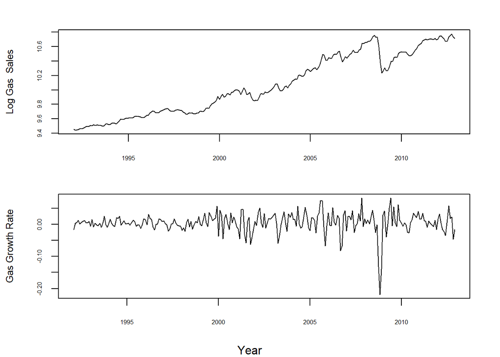

```r
gas.diff <- diff(gassa.log)
par(oma=c(2,0,0,0),mar=c(2,4,2,2)+0.1,mfrow=c(2,1),cex.lab=.8)
plot(gassa.log,xlab="",ylab="Log Gas  Sales",yaxt="n",xaxt="n")
axis(1,cex.axis=.5)
axis(2,cex.axis=.5)
plot(gas.diff,xlab="",ylab = "Gas Growth Rate",yaxt="n",xaxt="n")
axis(1,cex.axis=.5)
axis(2,cex.axis=.5)
mtext(text="Year",side=1,line=1,outer=TRUE)
```

## The Backward Shift

- We define the *backward shift* (or *lag*) operator $B$, which shifts a time series back one time unit. This is a linear filter that lags time by one unit:
  $$Y_t = X_{t-1}.$$
  So the filter weights are $\psi_1 = 1$ and zero otherwise. Informally we write $B X_t = X_{t-1}$.

## Powers of Backward Shift

- Then $X_{t-k} = B^k X_t$, and a general filter is expressed as
  $$Y_t = \sum_{k \in {\mathbb Z}} \psi_k \, X_{t-k}
  = \sum_{k \in {\mathbb Z}} \psi_k B^k \, X_{t},$$
  so we write the filter as $\sum_{k \in {\mathbb Z}} \psi_k B^k$. Call this $\Psi (B)$. (Mathematically, $\Psi (z)$ is a Laurent series.)

### Simple Moving Average Filter

- Expressed as $\Psi (B) = {(2m+1)}^{-1} \sum_{k = -m}^m B^k$.

## Differencing Filter

- Expressed as $\Psi (B) = 1 -B$.